# Clustering

PS239T

Fall 2015

### Setup Environment

First let’s load our required packages.

```r
setwd("~/Dropbox/berkeley/Dissertation/Data and Analyais/Git Repos/text-analysis-dhbsi")
rm(list=ls())
library(tm)
library(RTextTools)
library(lsa)
library(cluster)
library(fpc)
```

### Prepare Data

```r
# load corpus
docs <- Corpus(DirSource("Data/British_Fiction"))
docs
```

```
## <<VCorpus>>
## Metadata:  corpus specific: 0, document level (indexed): 0
## Content:  documents: 6
```

```r
# make DTM
dtm <- DocumentTermMatrix(docs)
dim(dtm)
```

```
## [1]     6 62725
```

```r
inspect(dtm[,100:104])
```

```
## <<DocumentTermMatrix (documents: 6, terms: 5)>>
## Non-/sparse entries: 5/25
## Sparsity           : 83%
## Maximal term length: 11
## Weighting          : term frequency (tf)
##
##                        Terms
## Docs                    _first_ _fondness_ _gaufres_ _gentleman_ _good_
##   Austen_Emma.txt             2          0         0           1      0
##   Austen_Pride.txt            0          0         0           0      0
##   Austen_Sense.txt            0          0         0           0      0
##   CBronte_Jane.txt            0          0         0           0      0
##   CBronte_Professor.txt       0          0         0           0      0
##   CBronte_Villette.txt        0          1         1           0      2
```

```r
# convert to matrix
dtm.m <- as.matrix(dtm)
```

# 1. Similarity and Distance

Arranging our texts in a document-term matrix make available a range of exploratory procedures. For example, calculating a measure of similarity between texts becomes simple. Since each row of the document-term matrix is a sequence of a novel’s word frequencies, it is possible to put mathematical notions of similarity (or distance) between sequences of numbers in service of calculating the similarity (or distance) between any two novels.

### 1.1 Euclidean Distance

One frequently used measure of distance between vectors (a measure easily converted into a measure of similarity) is Euclidean distance. The [Euclidean distance](https://en.wikipedia.org/wiki/Euclidean_distance) between two vectors in the plane should be familiar from geometry, as it is the length of the hypotenuse that joins the two vectors. For instance, consider the Euclidean distance between the vectos $\vec{x} = (1,3)$ and $\vec{y} = (4,2)$. The distance between the two vectors is $\sqrt{(1-4)^2 + (3-2)^2} = \sqrt{10}$

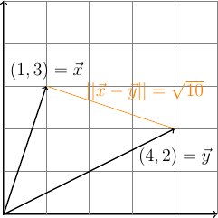

> **Note** Measures of distance can be converted into measures of similarity. If your measures of distance are all between zero and one, then a measure of similarity could be one minus the distance. (The inverse of the distance would also serve as a measure of similarity.)

This concept of distance is not restricted to two dimensions. For example, it is not difficult to imagine the figure above translated into three dimensions. We can also persuade ourselves that the measure of distance extends to an arbitrary number of dimensions.

Since two novels in our corpus now have an expression as vectors, we can calculate the Euclidean distance between them. We can do this by hand or we take advantages of the `dist` function in `r`.

```r
d <- dist(dtm.m, method = "euclidean")
d
```

```
##                       Austen_Emma.txt Austen_Pride.txt Austen_Sense.txt
## Austen_Pride.txt             2610.969
## Austen_Sense.txt             3025.633         1406.440
## CBronte_Jane.txt             4190.641         5133.135         5476.664
## CBronte_Professor.txt        4813.391         2876.584         2664.716
## CBronte_Villette.txt         4347.246         5252.719         5535.075
##                       CBronte_Jane.txt CBronte_Professor.txt
## Austen_Pride.txt
## Austen_Sense.txt
## CBronte_Jane.txt
## CBronte_Professor.txt         6446.811
## CBronte_Villette.txt          1887.369              6649.634
```

### 1.2 Cosine Similarity

And if we want to use a measure of distance that takes into consideration the length of the novels (an excellent idea), we can calculate the [cosine similarity](http://www.gettingcirrius.com/2010/12/calculating-similarity-part-1-cosine.html) by using the `cosine` function from the `lsa` package.

Unlike the `dist` function which compares distances between rows, the `cosine` function compares distances between columns. This means that we have the **transpose** our matrix before passing it into the `cosine` function.

```r
# transpose matrix
dtm.t <- t(dtm.m)
# calculate cosine metric
d <- cosine(dtm.t)
d
```

```
##                       Austen_Emma.txt Austen_Pride.txt Austen_Sense.txt
## Austen_Emma.txt             1.0000000        0.9805446        0.9722860
## Austen_Pride.txt            0.9805446        1.0000000        0.9833307
## Austen_Sense.txt            0.9722860        0.9833307        1.0000000
## CBronte_Jane.txt            0.9442509        0.9508863        0.9428045
## CBronte_Professor.txt       0.9426034        0.9567347        0.9547865
## CBronte_Villette.txt        0.9446430        0.9567980        0.9532699
##                       CBronte_Jane.txt CBronte_Professor.txt
## Austen_Emma.txt              0.9442509             0.9426034
## Austen_Pride.txt             0.9508863             0.9567347
## Austen_Sense.txt             0.9428045             0.9547865
## CBronte_Jane.txt             1.0000000             0.9873645
## CBronte_Professor.txt        0.9873645             1.0000000
## CBronte_Villette.txt         0.9877989             0.9918747
##                       CBronte_Villette.txt
## Austen_Emma.txt                  0.9446430
## Austen_Pride.txt                 0.9567980
## Austen_Sense.txt                 0.9532699
## CBronte_Jane.txt                 0.9877989
## CBronte_Professor.txt            0.9918747
## CBronte_Villette.txt             1.0000000
```

Keep in mind that cosine similarity is a measure of similarity (rather than distance) that ranges between 0 and 1 (as it is the cosine of the angle between the two vectors). In order to get a measure of distance (or dissimilarity), we need to “flip” the measure so that a larger angle receives a larger value. The distance measure derived from cosine similarity is therefore one minus the cosine similarity between two vectors.

```r
# convert to dissimilarity distances
d <- as.dist(1-d)
d
```

```
##                       Austen_Emma.txt Austen_Pride.txt Austen_Sense.txt
## Austen_Pride.txt          0.019455352
## Austen_Sense.txt          0.027713962      0.016669253
## CBronte_Jane.txt          0.055749102      0.049113706      0.057195459
## CBronte_Professor.txt     0.057396620      0.043265265      0.045213520
## CBronte_Villette.txt      0.055356959      0.043202009      0.046730097
##                       CBronte_Jane.txt CBronte_Professor.txt
## Austen_Pride.txt
## Austen_Sense.txt
## CBronte_Jane.txt
## CBronte_Professor.txt      0.012635465
## CBronte_Villette.txt       0.012201112           0.008125273
```

# 2. Visualizing distance with MDS

It is often desirable to visualize the pairwise distances between our texts. A general approach to visualizing distances is to assign a point in a plane to each text, making sure that the distance between points is proportional to the pairwise distances we calculated. This kind of visualization is common enough that it has a name, [“multidimensional scaling”](https://en.wikipedia.org/wiki/Multidimensional_scaling) (MDS)

```r
mds_scale<- cmdscale(d, k = 2)
fit <- cmdscale(d,eig=TRUE, k=2) # k is the number of dim
fit # view results
```

```
## $points
##                              [,1]          [,2]
## Austen_Emma.txt       -0.02978039  0.0145419261
## Austen_Pride.txt      -0.01995334 -0.0009094539
## Austen_Sense.txt      -0.02327752 -0.0145690471
## CBronte_Jane.txt       0.02750289  0.0117024319
## CBronte_Professor.txt  0.02299230 -0.0076847568
## CBronte_Villette.txt   0.02251606 -0.0030811002
##
## $eig
## [1]  3.618878e-03  6.300474e-04  6.355968e-05  3.283186e-05 -1.897354e-19
## [6] -1.927432e-04
##
## $x
## NULL
##
## $ac
## [1] 0
##
## $GOF
## [1] 0.9362867 0.9778171
```

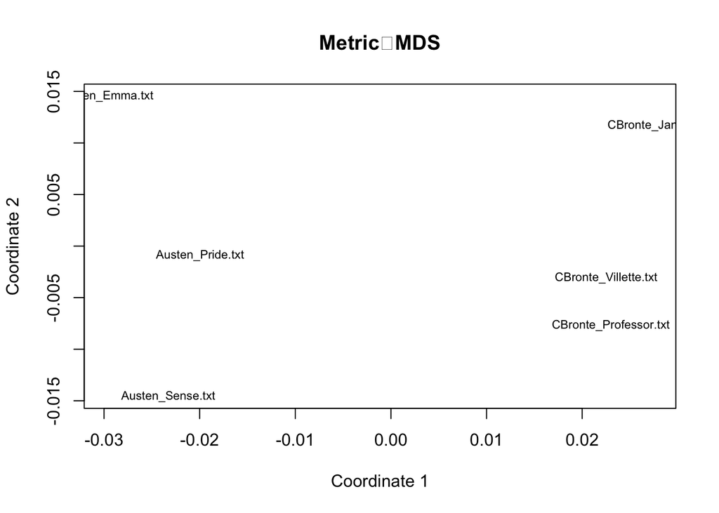

```r
# plot solution
x <- fit$points[,1]
y <- fit$points[,2]
plot(x, y, xlab="Coordinate 1", ylab="Coordinate 2",
  main="Metric  MDS",   type="n")
text(x, y, labels = row.names(dtm), cex=.7)
```

# 3. Clustering texts based on distance

Clustering texts into discrete groups of similar texts is often a useful exploratory step. For example, a researcher may be wondering if certain textual features partition a collection of texts by author or by genre. Pairwise distances alone do not produce any kind of classification. To put a set of distance measurements to work in classification requires additional assumptions, such as a definition of a group or cluster.

The ideas underlying the transition from distances to clusters are, for the most part, common sense. Any clustering of texts should result in texts that are closer to each other (in the distance matrix) residing in the same cluster. There are many ways of satisfying this requirement; there no unique clustering based on distances that is the “best.”

### 3.1 Hierarchical clustering based on distance

1. Start with each text in its own cluster
2. Find the closest clusters and merge them. The distance between two clusters is the change in the sum of squared distances when they are merged. Continue until only a single cluster remains.
3. Return a tree containing a record of cluster-merges.

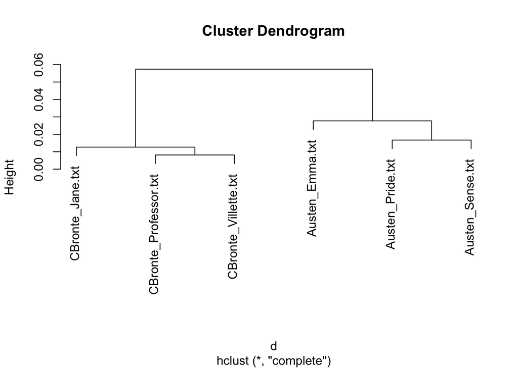

```r
# transpose matrix
dtm.t <- t(dtm.m)
# calculate cosine metric
d <- cosine(dtm.t)
# convert to dissimilarity distances
d <- as.dist(1-d)
# plot hierarchical cluster
plot(hclust(d))
```

### 3.2 K-means clusters

Another popular way to cluster text is a method called [k-means](https://en.wikipedia.org/wiki/K-means_clustering) which aims to partition `n` observations into `k` clusters in which each observation belongs to the cluster with the nearest mean, serving as a prototype of the cluster.

We can use the `kmean` function in r to perform this operation.

In the example below, we cluster based on the `cosine` distance matrix made above.

```r
set.seed(0001)
clust <- kmeans(d,2)

# check out clusters
clusters <- clust$cluster
clusters
```

```
##       Austen_Emma.txt      Austen_Pride.txt      Austen_Sense.txt
##                     1                     1                     1
##      CBronte_Jane.txt CBronte_Professor.txt  CBronte_Villette.txt
##                     2                     2                     2
```

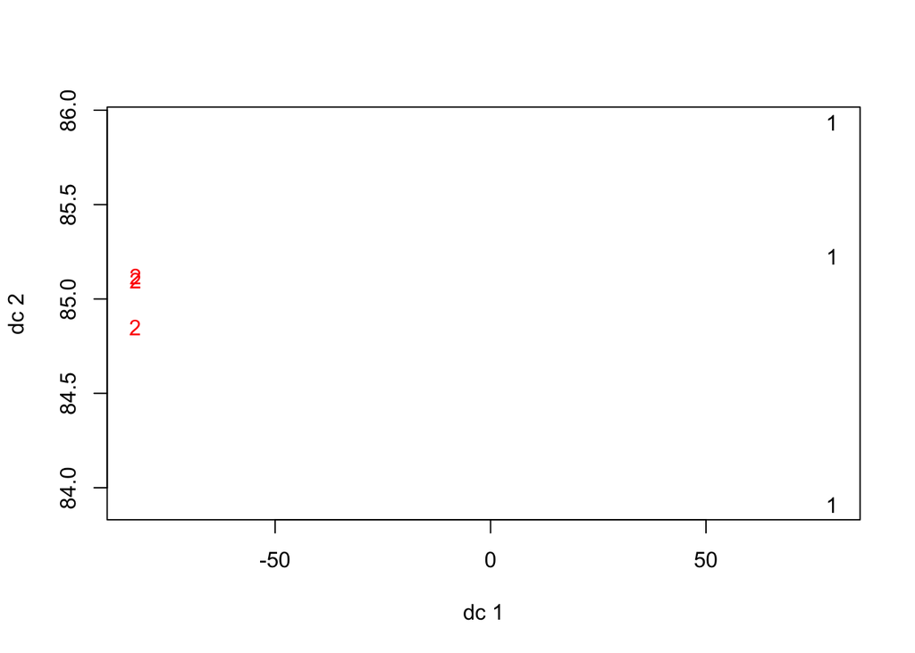

```r
plotcluster(d, clust$cluster)
```

k-means can also be used on the vectorized texts themselves. Notice the difference in results when we input the raw dtm.

```r
set.seed(0001)
clust <- kmeans(dtm.m,2)

# check out clusters
clusters <- clust$cluster
clusters
```

```
##       Austen_Emma.txt      Austen_Pride.txt      Austen_Sense.txt
##                     1                     1                     1
##      CBronte_Jane.txt CBronte_Professor.txt  CBronte_Villette.txt
##                     2                     1                     2
```

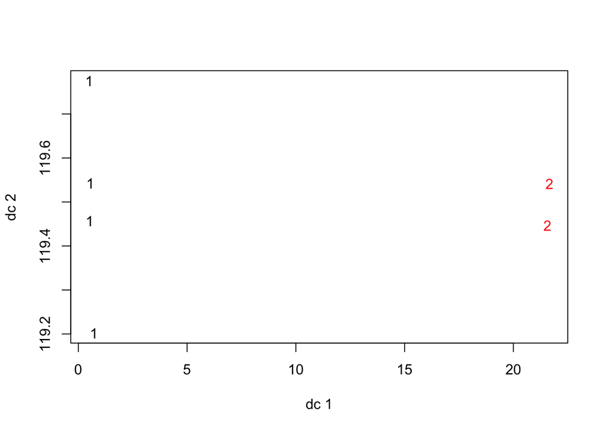

```r
plotcluster(d, clust$cluster)
```

It should be noted that k-means are very sensitive to feature scaling. Notice the difference in results once we’ve applied a tf-idf weighting procedure.

```r
# tf-idf weights
dtm.weighted <- DocumentTermMatrix(docs,
                      control = list(weighting =function(x) weightTfIdf(x, normalize = TRUE)))
dtm.weighted <- as.matrix(dtm.weighted)
dtm.weighted[,1:5]
```

```
##                        Terms
## Docs                         _______          _a_   _accepted_
##   Austen_Emma.txt       2.067143e-05 2.067143e-05 2.067143e-05
##   Austen_Pride.txt      0.000000e+00 0.000000e+00 0.000000e+00
##   Austen_Sense.txt      0.000000e+00 0.000000e+00 0.000000e+00
##   CBronte_Jane.txt      0.000000e+00 0.000000e+00 0.000000e+00
##   CBronte_Professor.txt 0.000000e+00 0.000000e+00 0.000000e+00
##   CBronte_Villette.txt  0.000000e+00 0.000000e+00 0.000000e+00
##                        Terms
## Docs                         _adair_   _addition_
##   Austen_Emma.txt       2.067143e-05 2.067143e-05
##   Austen_Pride.txt      0.000000e+00 0.000000e+00
##   Austen_Sense.txt      0.000000e+00 0.000000e+00
##   CBronte_Jane.txt      0.000000e+00 0.000000e+00
##   CBronte_Professor.txt 0.000000e+00 0.000000e+00
##   CBronte_Villette.txt  0.000000e+00 0.000000e+00
```

```r
# cluster
set.seed(0001)
clust <- kmeans(dtm.weighted,2)

# check out clusters
clusters <- clust$cluster
clusters
```

```
##       Austen_Emma.txt      Austen_Pride.txt      Austen_Sense.txt
##                     1                     2                     2
##      CBronte_Jane.txt CBronte_Professor.txt  CBronte_Villette.txt
##                     2                     2                     2
```

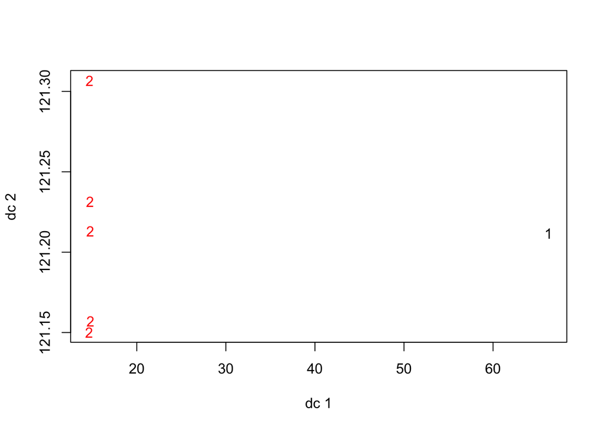

```r
plotcluster(d, clust$cluster)
```

### Exercise: Perform kmeans on a simple normalized matrix.

Yet another way to scale features is simple frequency normalization. Try it out yourself.

```r
# normalized without weights
dtm.normalized <- dtm.m/rowSums(dtm.m)
dtm.normalized[,1:5]
```

```
##                        Terms
## Docs                         _______          _a_   _accepted_
##   Austen_Emma.txt       7.996801e-06 7.996801e-06 7.996801e-06
##   Austen_Pride.txt      0.000000e+00 0.000000e+00 0.000000e+00
##   Austen_Sense.txt      0.000000e+00 0.000000e+00 0.000000e+00
##   CBronte_Jane.txt      0.000000e+00 0.000000e+00 0.000000e+00
##   CBronte_Professor.txt 0.000000e+00 0.000000e+00 0.000000e+00
##   CBronte_Villette.txt  0.000000e+00 0.000000e+00 0.000000e+00
##                        Terms
## Docs                         _adair_   _addition_
##   Austen_Emma.txt       7.996801e-06 7.996801e-06
##   Austen_Pride.txt      0.000000e+00 0.000000e+00
##   Austen_Sense.txt      0.000000e+00 0.000000e+00
##   CBronte_Jane.txt      0.000000e+00 0.000000e+00
##   CBronte_Professor.txt 0.000000e+00 0.000000e+00
##   CBronte_Villette.txt  0.000000e+00 0.000000e+00
```

```r
### YOUR CODE HERE TO CLUSTER
```

Which feature scaling worked best?